# Week 9: Assignment 8, Part 2

Your name

In this assignment, you will analyze the political twitter accounts during the campaign of the 2017 UK General Election. The twitter data is available in a dropbox folder (see below). Each data file contains the tweets from candiadtes and parties, and the replies to these accounts.

https://www.dropbox.com/sh/ktl1a3672yl6te0/AAA2At9pSt9hZ-KsaT0Mwbp2a?dl=0

The file is compressed. When I collected the data, I saved the streamed twitter data every 15 minutes. The condition of streaming is to get the all tweets from the candidates and party official accounts and replies directly sent to these accounts. I randomy selected 10 percent of data files for this assignment. This repository also contains the candiate twitter account information (`candidate_tweet_data_pset8.rda`), so that you can find which are the politician/parties tweets and which are the replies to the accounts.

## Download the data and put in a sqlite database

There are 113 `tar.gz` files in the folder. In this section, you are asked to process all files into the data set. There can be several strategies, such as using the methods you have already learned in the previous assignments (c.f. `parseTweets`), or you can try an R-package **readtext**.

### Create a database

```r
library(dplyr)
library(DBI)

db <- dbConnect(RSQLite::SQLite(), "~/Data/my472/ge_2017.sqlite" )
```

### Create two tables and import the data (15 points)

Each JSON file includes both twitter information and user information. You will separate the fields and create two tables: `tweets` and `users`. When you include the data, make sure that there is no duplicates in the `users` and `tweets` table (i.e. `tweet_id` is unique in tweets table, and `user_id` is unique in `users` table). Also make sure that these two tables can be combined afterwards using a field common to two tables. Part of `candidate_tweet_data_pset8.rda` can be in the `users` for the future analysis purpose (at least you need to know which accounts are parties and candidates).

```r
filenames <- list.files("~/Dropbox/GE2017/my472/ge2017/", pattern = "tar.gz", full.names = TRUE)
load("~/Dropbox/LSE_Courses/MY472_workingDir/AM_ProblemSets/pset8/candidate_tweet_data_pset8.rda")

library(readtext)
tweet_data_all <- user_data_all <- NULL
i <- 1
for(fn in filenames){
  message(i)
  i <- i + 1
  message(fn)
  data <- readtext(fn, source = "twitter")
  data <- data %>%
    mutate(screen_name_in = screen_name %in% candidate_tweet_data_pset8$screenName) %>%
    mutate(in_reply_to_screen_name_in = in_reply_to_screen_name %in% candidate_tweet_data_pset8$screenName) #%>%
    #group_by(in_reply_to_screen_name_in, screen_name_in) %>% summarise(count = n())
  tweet_data <- data %>% select(c(1:15, 18, 33:44))
  tweet_data_all[[length(tweet_data_all) + 1]] <- tweet_data
  user_data <- data %>% select(16:32)
  user_data_all[[length(user_data_all) + 1]] <- user_data

}
tweet_data_combined <- bind_rows(tweet_data_all) %>%
  mutate(created_at_dt = created_at %>% strptime("%a %b %d %H:%M:%S %z %Y", tz = "GMT") %>%
            as.POSIXct(tz = "GMT"))
# tweet_data_combined$created_at %>% head()
user_data_combined <- bind_rows(user_data_all) %>%
  filter(!duplicated(user_id_str)) %>%
  mutate(user_created_at_dt = user_created_at %>% strptime("%a %b %d %H:%M:%S %z %Y", tz = "GMT") %>%
            as.POSIXct(tz = "GMT") ) %>%
  mutate(screen_name_in = screen_name %in% candidate_tweet_data_pset8$screenName)
# user_data_combined$user_created_at %>% head()
dbSendQuery(db, "DROP TABLE IF EXISTS tweets")
dbWriteTable(db, "tweets", tweet_data_combined)
dbSendQuery(db, "DROP TABLE IF EXISTS users")
dbWriteTable(db, "users", user_data_combined)

dbGetQuery(db, "SELECT * FROM tweets LIMIT 1") %>% str()
dbDisconnect(db)
```

### Check the data (2 points)

How many tweets are in the `tweets` table? How many unique users?

```r
dbGetQuery(db, "SELECT COUNT(*) FROM tweets")
```

```
##   COUNT(*)
## 1   221711
```

```r
dbGetQuery(db, "SELECT COUNT(*) FROM users")
```

```
##   COUNT(*)
## 1    91256
```

### Description of the data (21 points, 3 per question)

Answer the following questions (again try to do most aggregation in the query, not in R):

1. Which screen_name has the highest count of tweets?
2. Who has the highest number of followers?
3. Among politicians, who has the highest number of followers ?
4. Which tweet has the earliest timestamp in the data? Which is the latest?
5. Who were the top ten most replied account? How many times?
6. How many tweets with the word brexit?
7. How many tweets have geolocation information (`lat` or `lon` value)? (You’d be surprised how small the number is.)

```r
# 1.
dbGetQuery(db,
'SELECT screen_name, COUNT(*) AS tweet_count
FROM tweets AS t
JOIN users AS u ON t.user_id_str = u.user_id_str
GROUP BY screen_name
ORDER BY tweet_count DESC
LIMIT 1')
```

```
##   screen_name tweet_count
## 1 labour_zone        1621
```

```r
# 2.
dbGetQuery(db,
'SELECT screen_name, followers_count
FROM users
ORDER BY followers_count DESC
LIMIT 1')
```

```
##    screen_name followers_count
## 1 rickygervais        12419966
```

```r
# 3.
dbGetQuery(db,
'SELECT screen_name, name, followers_count, u.user_id_str
FROM tweets AS t
JOIN users AS u ON t.user_id_str = u.user_id_str
WHERE u.screen_name_in = 1
ORDER BY followers_count DESC
LIMIT 1')
```

```
##    screen_name          name followers_count user_id_str
## 1 jeremycorbyn Jeremy Corbyn          968629   117777690
```

```r
# 4.
dbGetQuery(db,
'SELECT t.id_str, screen_name, name, created_at_dt, created_at
FROM tweets AS t
JOIN users AS u ON t.user_id_str = u.user_id_str
WHERE u.screen_name_in = 1
ORDER BY created_at_dt DESC
LIMIT 1')
```

```
##               id_str     screen_name            name created_at_dt
## 1 872728644896141312 DeanPalethorpe1 Dean Palethorpe    1496909698
##                       created_at
## 1 Thu Jun 08 08:14:58 +0000 2017
```

```r
# 5.
dbGetQuery(db,
'SELECT screen_name, COUNT(*) AS reply_count
FROM tweets AS t
JOIN users AS u ON t.in_reply_to_user_id_str = u.user_id_str
GROUP BY screen_name
ORDER BY reply_count DESC
LIMIT 10')
```

```
##        screen_name reply_count
## 1    Conservatives        8590
## 2     jeremycorbyn        7533
## 3     BorisJohnson        3656
## 4         UKLabour        1504
## 5    HackneyAbbott         888
## 6      Jeremy_Hunt         816
## 7    JamesCleverly         472
## 8  paulnuttallukip         464
## 9          LibDems         420
## 10   BarryGardiner         405
```

```r
# 6.
dbGetQuery(db,
'SELECT COUNT(*) FROM tweets WHERE text LIKE "%brexit%"')
```

```
##   COUNT(*)
## 1     9028
```

```r
# 7.
dbGetQuery(db,
'SELECT CASE WHEN lat IS NOT NULL THEN 1 ELSE 0 END AS has_geo,
        COUNT(*)
FROM tweets AS t
JOIN users AS u ON t.user_id_str = u.user_id_str
GROUP BY has_geo')
```

```
##   has_geo COUNT(*)
## 1       0   221676
## 2       1       35
```

### Hashtags and mentions (15 points)

We can analyze twitter hashtags and mentions pretty easilty with `quanteda`. Read https://quanteda.io/articles/pkgdown/examples/twitter.html and answer following questions. For creating dfm, you need to create a corpus from a dataframe you created from a sql database.

1. What are the top 10 popular hashtags? How many of them shows up?
2. In the network of hashtags, what do you find?
3. Who was mentioned (i.e. ‘@name’) the most? How the mentions and hashtags are related?

```r
library(quanteda)
text_data <- dbGetQuery(db,
'SELECT id_str, text, screen_name, created_at_dt FROM tweets
JOIN users ON tweets.user_id_str = users.user_id_str
')



tweet_dfm <- dfm(corpus(text_data), remove_punct = TRUE)
tag_dfm <- dfm_select(tweet_dfm, ('#*'))
toptag <- names(topfeatures(tag_dfm, 50))
head(toptag)
```

```
## [1] "#ge2017"            "#forthemany"        "#votelabour"
## [4] "#battlefornumber10" "#bbcdebate"         "#facupfinal"
```

```r
head(tweet_dfm)
```

```
## Document-feature matrix of: 6 documents, 99,806 features (100.0% sparse).
```

```r
tag_fcm <- fcm(tag_dfm)
head(tag_fcm)
```

```
## Feature co-occurrence matrix of: 6 by 6 features.
## 6 x 6 sparse Matrix of class "fcm"
##                 features
## features         #leeds #ge2017 #cherry4edinsw #ge17 #labour #harborough
##   #leeds              0      74              0     2       0           0
##   #ge2017             0       2             34    47      84          49
##   #cherry4edinsw      0       0              0    12       0           0
##   #ge17               0       0              0     0      10           3
##   #labour             0       0              0     0       3           4
##   #harborough         0       0              0     0       0           0
```

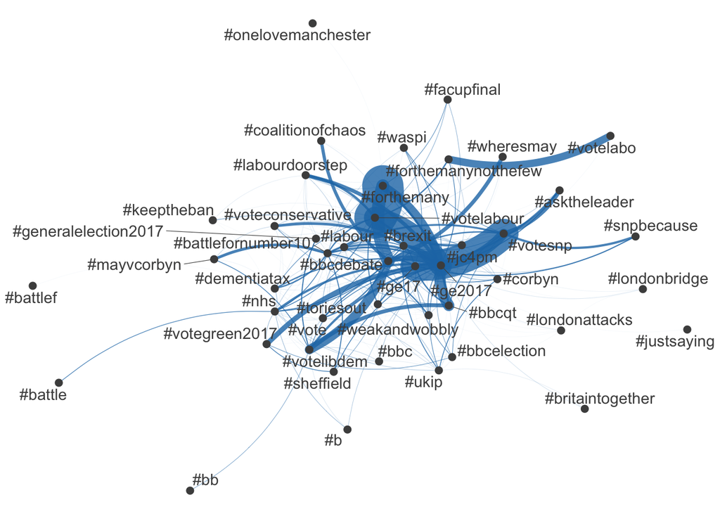

```r
topgat_fcm <- fcm_select(tag_fcm, toptag)
textplot_network(topgat_fcm, min_freq = 0.1, edge_alpha = 0.8, edge_size = 5)
```

```r
tag_mention_dfm <- dfm_select(tweet_dfm, ('#*|@*'))
toptag_mention <- names(topfeatures(tag_mention_dfm, 50))

tag_mention_fcm <- fcm(tag_mention_dfm)
head(tag_mention_fcm)
```

```
## Feature co-occurrence matrix of: 6 by 6 features.
## 6 x 6 sparse Matrix of class "fcm"
##                 features
## features         @benrich66 @libdems @angelarayner @aw_bell @molly4bristol
##   @benrich66              0        1             0        0              0
##   @libdems                0      124             0        0              0
##   @angelarayner           0        0            11        0              0
##   @aw_bell                0        0             0        0              6
##   @molly4bristol          0        0             0        0              2
##   @bcfmra                 0        0             0        0              0
##                 features
## features         @bcfmra
##   @benrich66           0
##   @libdems             0
##   @angelarayner        0
##   @aw_bell             1
##   @molly4bristol       1
##   @bcfmra              0
```

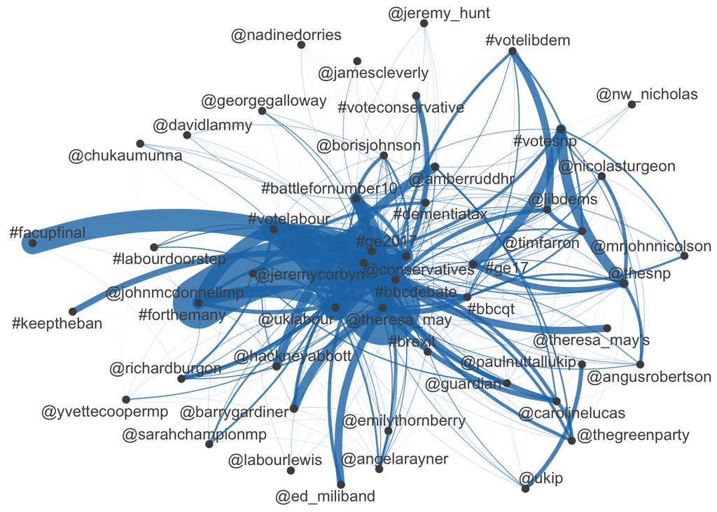

```r
tag_mention_fcm <- fcm_select(tag_mention_fcm, toptag_mention)
textplot_network(tag_mention_fcm, min_freq = 0.1, edge_alpha = 0.8, edge_size = 5)
```

4. Create a `hashtag` from where there are two fields (`id_str`, `hashtag`). You can use only top 50 hashtags. The example entary of the table looks like this (HINT: `quanteda::docvars`, `quanteda::convert`, `tidyr::gather`)

```r
load('sample_hashtag_table_entry.rda')
sample_hashtag_table_entry %>% knitr::kable()
```

| id_str | hashtag |
| --- | --- |
| 869314177449545731 | #forthemany |
| 872704676612984832 | #votelabour |
| 869291650543222785 | #dementiatax |
| 869938878655889408 | #keeptheban |
| 870963056452435969 | #ge2017 |
| 869172180113817602 | #votelabour |
| 872582501931393024 | #votelabour |
| 872440952736100352 | #votelabour |
| 872726156717547520 | #forthemany |
| 869292093830836224 | #dementiatax |

```r
tag_dfm <- dfm_select(tag_dfm, names(topfeatures(tag_dfm, 50)))
tag_dfm_df <- convert(tag_dfm, to = "data.frame") %>% select(-document)
tag_dfm_df$id_str <- docvars(tag_dfm, "id_str")
```

There are several ways to answer this questin, but using `gather()` from `tidyr` would be the simplest.

```r
library(tidyverse)
tag_dfm_df_long <- tag_dfm_df %>% gather(hashtag, value, 1:50) %>%
  filter(value >0 ) %>% select(1:2)
set.seed(10)
sample_hashtag_table_entry <- tag_dfm_df_long %>% sample_n(10)
rownames(sample_hashtag_table_entry) <- NULL
save(sample_hashtag_table_entry, file = "sample_hashtag_table_entry.rda")
dbWriteTable(db, 'hashtag', tag_dfm_df_long)
```

### Timesries and cross-sectional plot (12 points)

Think about an interesting aggregation of tweets chronologically and draw figures (more than one). You can aggregate the number of tweets by day plus another criteria (e.g. party? hashtags?). Construct a story from the data (preferably that has both time and cross-sectional (e.g. regional/party etc) demension), and support it with table(s) and figure(s).